# Reproducing the *Diana in the World of Men* paper

Pete Jones

## Introduction

> “Be careful in the world of men, Diana. They don’t deserve you.”

> — Hippolyta, Queen of the Amazons, in *Wonder Woman*.

In this notebook I will walk through the process of reproducing the analysis in [my 2018 paper](https://doi.org/10.1080/14680777.2018.1510846) exploring the gendered character positions in *Wonder Woman*[^1] from the raw dialogue data. The paper compares gendered character positions in *Wonder Woman* with two other films: *Thor* (2011) and *The Hunger Games* (2012).

Make sure that the data folder is in the same directory as this notebook. The following packages will also need to be installed and loaded for the code to run smoothly:

```r
# install.packages("extrafont")
# install.packages("igraph")
# install.packages("ggplot2")
# install.packages("ggraph")
# install.packages("graphlayouts")
# install.packages("network")
# install.packages("scales")
# install.packages("visNetwork")

library(igraph, warn.conflicts = FALSE, quietly = TRUE)
library(ggraph, quietly = TRUE)
library(graphlayouts, quietly = TRUE)
library(extrafont, quietly = TRUE)
library(network, quietly = TRUE)
library(scales, quietly = TRUE)
library(visNetwork, quietly = TRUE)
```

## *Wonder Woman*

### Reading in the *Wonder Woman* data

Building on the previous notebook `01-FilmPipeline.Rmd`, we will source in the functions and follow most of the steps of that pipeline.

```r
source("film-functions.R")
```

Now we can read in the raw data,

```r
ww_data <- qread_film("data/ww_lines.csv", "data/ww_chars.csv")
```

and check it for errors.

```r
check_for_errors(ww_data$adjacency, ww_data$event_list)
```

```
## No characters with self-ties found.
## No empty rows found.
```

### Is *Wonder Woman* female-led?

One of the arguments made in the paper is that the character interaction network data for *Wonder Woman* calls into question the idea that the film is ‘female-led’.

We can find evidence for this claim in the node list for the film, which is where the figures for the number of lines spoken and received by each character can be found.

```r
knitr::kable(ww_data$node_list)
```

| char_ID | char_name | char_female | nlines | linesin | gender |
| --- | --- | --- | --- | --- | --- |
| 1 | Diana | 1 | 222 | 308 | Female |
| 2 | Hippolyta | 1 | 41 | 39 | Female |
| 3 | Antiope | 1 | 17 | 18 | Female |
| 4 | Menalippe | 1 | 7 | 14 | Female |
| 5 | Steve Trevor | 0 | 265 | 234 | Male |
| 6 | Artemis | 1 | 1 | 10 | Female |
| 7 | Venelia | 1 | 1 | 11 | Female |
| 8 | Philippus | 1 | 2 | 11 | Female |
| 9 | Isabel Maru | 1 | 13 | 14 | Female |
| 10 | General Ludendorff | 0 | 21 | 20 | Male |
| 11 | Senator Acantha | 1 | 1 | 11 | Female |
| 12 | Epione | 1 | 2 | 11 | Female |
| 13 | Etta Candy | 1 | 24 | 19 | Female |
| 14 | Sir Patrick | 0 | 37 | 33 | Male |
| 15 | Col. Darnell | 0 | 7 | 13 | Male |
| 16 | Field Marshall Haig | 0 | 9 | 18 | Male |
| 17 | Sameer | 0 | 44 | 65 | Male |
| 18 | Charlie | 0 | 29 | 54 | Male |
| 19 | Von Hindenberg | 0 | 4 | 5 | Male |
| 20 | The Chief | 0 | 22 | 43 | Male |

As we can see, Diana speaks notably less than Steve. As well as this, we can see that Diana is spoken to more than she speaks, while Steve speaks more than he is spoken to.

Is this just an anomaly (e.g. the result of a couple of scenes where he speaks much more than her)? In the paper, I argued that *no*, it is not an anomaly, as:

> Beginning with the first scene in which Steve speaks, Steve has more lines than Diana in 69.6% of all ensuing scenes in which one of the two characters speaks.

To show how I got that figure, I created a test to check exactly that:

```r
steve_speaks_more <- function(lines = ww_data$event_list) {
  # The first scene in which Steve speaks
  steve_scene_1 <- lines[min(which(lines[ , 3] == 5)), 2]
  # The first line in the first scene in which Steve speaks
  enter_steve <- min(which(lines[ , 2] == steve_scene_1))
  # The lines spoken by Steve or Diana:
  sdlines <- which(lines[enter_steve:nrow(lines), 3] %in% c(1, 5)) +
    (enter_steve - 1)
  # Get the scenes in which at least one of them speaks:
  sdscenes <- unique(lines[sdlines, 2])
  # Create a vector to store whether Steve speaks more in each of these scenes
  steve_wins <- vector(mode = "logical", length = length(sdscenes))
  # Find the percentage of these scenes in which Steve speaks more than Diana
  k <- 0
  for (scene in sdscenes) {
    k <- k + 1
    # test whether Steve's lines outnumber Diana's lines in each scene
    steve_wins[k] <- length(which(lines[ , 2] == scene & lines[ , 3] == 5)) >
      length(which(lines[ , 2] == scene & lines[ , 3] == 1))
  }
  # Print the percentage which are TRUE (i.e. Steve speaks more)
  round((length(which(steve_wins) == TRUE) / length(steve_wins)) * 100,
        digits = 2)
}
```

Which, when run, tells us:

```r
steve_speaks_more()
```

```
## [1] 69.57
```

So it’s clear that Steve does more of the talking than Diana. The summary table for the distribution of dialogue and named speaking characters by gender suggests that the pattern holds for males and females in general in the film:

```r
film_summary_gender(ww_data$node_list)
```

```
##  % characters female % lines out female % lines in female
##                   55              43.04                49
```

Although 55% of the speaking characters (11 out of 20) are female, only 43% of the lines are actually spoken by women. Female characters are more likely to be the recipients of dialogue than to speak, and the reverse is true for men.

This illustrates another key claim in the paper: we should be aware of the limitations of knowing only the gendered distribution of speaking characters when thinking about the marginalisation of women’s voices in Hollywood cinema.

Yearly reports from the [Annenberg Inclusion Initiative](https://annenberg.usc.edu/research/aii#inequality) and the [Centre for the Study of Women in Television and Film](https://womenintvfilm.sdsu.edu/wp-content/uploads/2019/02/2018_Its_a_Mans_Celluloid_World_Report.pdf) tell us what percentage of speaking characters in top-grossing films are female, typically finding the figure to be around 30%. This is the most sophisticated systematic evidence we have on the marginalisation of the female voice in mainstream Hollywood narratives.

However, the *Wonder Woman* data illustrates the limitations of relying on such figures, as the distributions of speaking characters and dialogue diverge significantly (largely due to the fact that 8 of the 11 female characters do not appear on screen at all in the final 102 minutes of the film).

This should serve as a reminder that when content analyses tell us that 30% of the speaking characters in a given year were female, this does not mean that 30% of the dialogue was actually spoken by women.

The numbers so far raise questions over the idea that *Wonder Woman* is a “female-led” film.

These questions are further illustrated by plotting the graph:

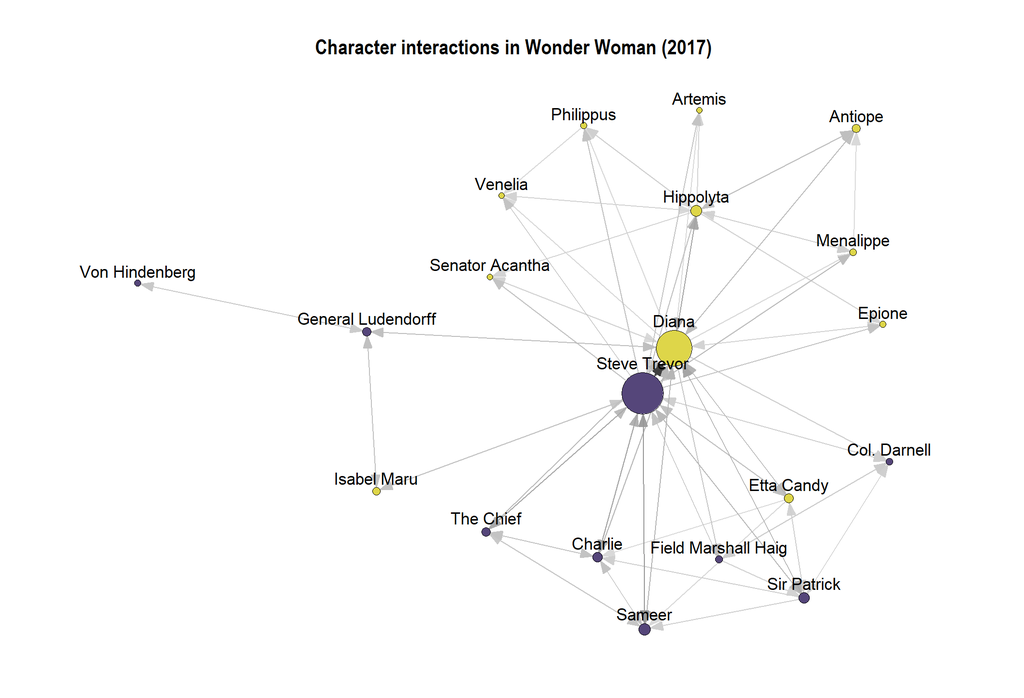

```r
plot_film_gg(ww_data$adjacency, ww_data$node_list,
             filmtitle = "Wonder Woman (2017)")
```

We can see that Steve and Diana occupy virtually the same positions in the character interaction system, and Diana’s neighbourhood is nearly identical to Steve’s. In fact…

How many characters does Diana speak to?

```r
length(which(ww_data$adjacency[1, ] > 0))
```

```
## [1] 17
```

One of these is Steve, so that leaves 16 characters in Diana’s neighbourhood that Steve could also talk to. How many does he actually talk to?

```r
sum(which(ww_data$adjacency[5, ] > 0) %in% which(ww_data$adjacency[1, ] > 0))
```

```
## [1] 14
```

Steve speaks to 14 of the 16 characters in Diana’s neighbourhood that aren’t him. Of the two he doesn’t also speak to, one is Antiope, who dies in the scene in which Steve is introduced.

From this perspective, it is hard to see how we could describe Diana as independent from Steve, when it seems that almost all of her character interactions need to be reinforced by Steve. Her narrative is *their* narrative.

### Power-with

Another thing which is evident from the network diagram is that, factoring in the fact that the Amazons do not appear in the final 102 minutes of the film, Diana has very few opportunities to interact with other women. Once she leaves Themyscira with Steve, she really is in the World of Men, where the only other women are a secretary and a disfigured chemist, both of whom work in service of much more central male characters. This means that there are no opportunities for a collective mode of empowerment in the film, wherein women work together and find strength in solidarity. in the end, the strength Diana finds to overcome Ares is not rooted in any kind of collective empowerment, it is rooted in the heroic sacrifice of her male sidekick Steve. Indeed, the vast majority of the narrative activity flows between these two characters.

## *Thor*

We can compare the *Wonder Woman* data with the data from the 2011 Marvel Studios film *Thor*. There are a lot of similarities between the films which make for a fruitful comparison: both are superhero action film adaptations of iconic mainstream comic book characters; both are estimated to have had a $150 million budget and were marketed to similar audiences; the title characters of both films are demigods whose story is drawn from classical mythology; in the plot of each film, the character travels from their mythical homeland to the earth of mortals familiar to the audience, creating a fish-out-of-water narrative in the second half of each film; and both characters are assisted by a mortal love interest character of the opposite sex.

Let’s read in the film, this time specifying names for the objects so we can keep everything in the same workspace.

```r
thor_data <- qread_film("data/thor_lines.csv", "data/thor_chars.csv")
```

```r
check_for_errors(thor_data$adjacency, thor_data$event_list)
```

```
## No characters with self-ties found.
## No empty rows found.
```

Take a look at the distribution of dialogue and characters by gender:

```r
film_summary_gender(thor_data$node_list)
```

```
##  % characters female % lines out female % lines in female
##                21.05              27.37             25.94
```

Take a look at the character stats:

```r
knitr::kable(thor_data$node_list)
```

| char_ID | char_name | char_female | nlines | linesin | gender |
| --- | --- | --- | --- | --- | --- |
| 1 | Jane Foster | 1 | 108 | 103 | Female |
| 2 | Darcy Lewis | 1 | 26 | 33 | Female |
| 3 | Erik Selvig | 0 | 54 | 69 | Male |
| 4 | Thor | 0 | 140 | 162 | Male |
| 5 | Odin | 0 | 42 | 40 | Male |
| 6 | Loki | 0 | 77 | 76 | Male |
| 7 | Volstagg | 0 | 21 | 37 | Male |
| 8 | Fandral | 0 | 12 | 42 | Male |
| 9 | Hogun | 0 | 5 | 36 | Male |
| 10 | Sif | 1 | 18 | 43 | Female |
| 11 | Heimdall | 0 | 19 | 20 | Male |
| 12 | King Laufey | 0 | 14 | 14 | Male |
| 13 | Phil Coulson | 0 | 24 | 21 | Male |
| 14 | Frigga | 1 | 7 | 7 | Female |
| 15 | Jasper Sitwell | 0 | 4 | 3 | Male |
| 16 | Clint Barton | 0 | 3 | 3 | Male |
| 17 | Agent Garrett | 0 | 2 | 1 | Male |
| 18 | Agent Jackson | 0 | 1 | 3 | Male |
| 19 | Nick Fury | 0 | 4 | 4 | Male |

And plot the network:

[figure not shown]

```r
plot_film_gg(thor_data$adjacency, thor_data$node_list, "Thor (2011)")
```

What does the *Thor* data show? Firstly, the hero-sidekick dynamic found in *Wonder Woman* plays out quite differently in *Thor*. Thor clearly speaks more lines than his sidekick Jane Foster. Moreover, Thor’s neighbourhood is larger than and independent from that of Jane - Thor speaks to 12 characters, of whom Jane speaks to only 3 (Jane speaks to only 5 characters in total. Thor’s interactions don’t need to be reinforced by Jane, and the narrative is enacted in much broader terms than the heteroromantic dyad of Jane and Thor. Unlike Diana in *Wonder Woman*, Thor is the clear leader of the narrative in *Thor*.

## *The Hunger Games*

Finally, we can compare the results with the 2012 film *The Hunger Games*, which has attracted a lot of discussion for its gender representation.

Read in the film:

```r
thg_data <- qread_film("data/thg_lines.csv", "data/thg_chars.csv")
```

```r
check_for_errors(thg_data$adjacency, thg_data$event_list)
```

```
## No characters with self-ties found.
## No empty rows found.
```

Take a look at the distribution of dialogue and characters by gender:

```r
film_summary_gender(thg_data$node_list)
```

```
##  % characters female % lines out female % lines in female
##                42.86              45.41             50.74
```

Take a look at the character stats:

```r
knitr::kable(thg_data$node_list)
```

| char_ID | char_name | char_female | nlines | linesin | gender |
| --- | --- | --- | --- | --- | --- |
| 1 | Seneca Crane | 0 | 18 | 24 | Male |
| 2 | Caesar Flickerman | 0 | 46 | 40 | Male |
| 3 | Katniss Everdeen | 1 | 189 | 254 | Female |
| 4 | Prim Everdeen | 1 | 12 | 28 | Female |
| 5 | Gale Hawthorne | 0 | 26 | 33 | Male |
| 6 | Effie Trinket | 1 | 33 | 15 | Female |
| 7 | Peeta Mellark | 0 | 108 | 126 | Male |
| 8 | Haymitch Abernathy | 0 | 55 | 46 | Male |
| 9 | Claudius Templesmith | 0 | 6 | 12 | Male |
| 10 | Flavius | 0 | 1 | 1 | Male |
| 11 | Cinna | 0 | 22 | 19 | Male |
| 12 | President Snow | 0 | 17 | 11 | Male |
| 13 | Atala | 1 | 1 | 0 | Female |
| 14 | Venia | 1 | 1 | 2 | Female |
| 15 | Glimmer | 1 | 6 | 10 | Female |
| 16 | Cato | 0 | 14 | 15 | Male |
| 17 | Fox Face | 1 | 1 | 3 | Female |
| 18 | Rue | 1 | 20 | 26 | Female |
| 19 | Marvel | 0 | 4 | 5 | Male |
| 20 | Clove | 1 | 4 | 7 | Female |
| 21 | Thresh | 0 | 4 | 3 | Male |

And plot the network:

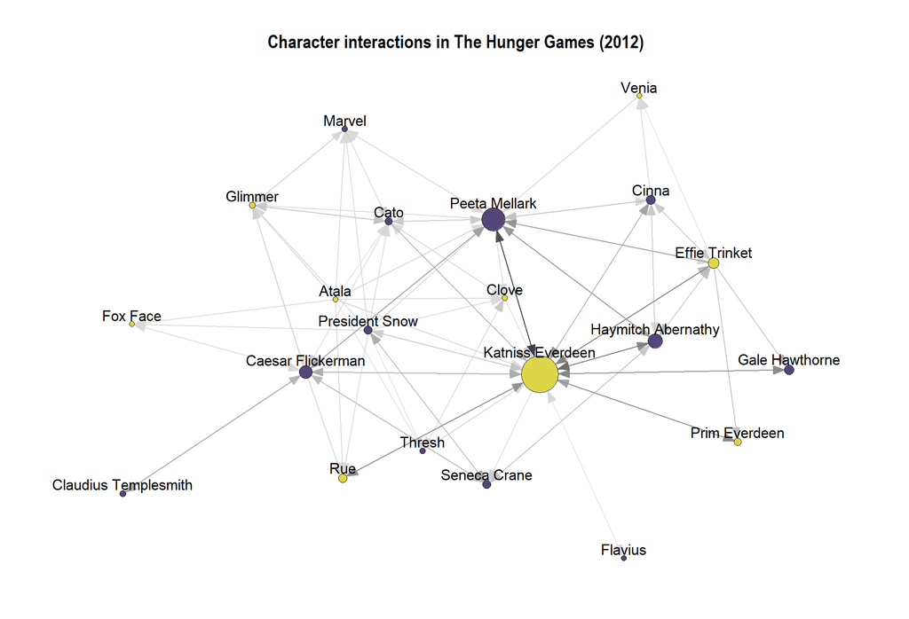

```r
plot_film_gg(thg_data$adjacency, thg_data$node_list, "The Hunger Games (2012)")
```

Again, The Hunger Games shows very different narrative patterns to Wonder Woman. Katniss speaks 81 more lines than any other character and is spoken to more than twice as much as anyone else. Katniss also charts her own way through the narrative, interacting with 12 other named speaking characters in the film. Of these 12, Peeta speaks only to 5, Haymitch speaks to 3, and Gale speaks to none. Katniss’ narrative is much broader than any of these male characters.

Although only 43% of the named speaking characters are female (compared with *Wonder Woman*’s 55%), female characters speak a higher share of the lines of dialogue in *The Hunger Games* (45%) than in *Wonder Woman* (43%). Again, this is a reminder of the limitations of knowing only the proportion of speaking characters that are female as a metric of the vocal dimension of narrative marginalisation.

Finally, although Katniss is the clear vocal leader and narrative focus of *The Hunger Games*, her position is not one of isolation among men, leading to an individualised sense of empowerment-as-exceptionalism. Katniss’ strength is rooted in a number of positive relationships – with her sister Prim, with her mentor Effie, and most notably with fellow tribute Rue, with whom Katniss forms an alliance in the arena which aims to subvert the violence of the Games through wits, shared knowledge and solidarity. Strong female characters can be strong in ways that show the importance of female relationships to one’s empowerment.

## Conclusion

The upshot of all this, as I argue in the paper, is that it seems that *Wonder Woman* is not quite as ‘female-led’ as it first appears, contrary to the strong claims made in the critical reception to the film. The narrative follows not Diana as an individual so much as it follows the Steve-Diana dyad (a dyad which is led by Steve). Diana’s strength is rooted in Steve. The patterns that are revealed from looking at the interaction network data ask us to think a little differently about the kind of narrative offered by *Wonder Woman*, and the kind of empowerment its hero represents. *Thor* shows us how a similar story can play out through a narrative which establishes a more independent hero, while *The Hunger Games* shows us how a strong female character can feature in a narrative in ways which not only establish her as a clear, independent leader, but also develop her empowerment through relationships with other female characters.

That’s about it for the material in the paper. Hopefully this notebook has:

- provided some transparency for the analyses in the paper.
- provided an example of the character interaction network approach in action.

Check out the next notebook `03-WonderWoman-text.Rmd` for some additional bits of text analysis on *Wonder Woman* I added after the original piece was published.

#### Using the data

If you want to use the data for anything (e.g. doing your own analysis, or just using it as a teaching dataset), please feel free. The citation is:

Jones, Pete. 2018. “Diana in the World of Men: a character network approach to analysing gendered vocal representation in *Wonder Woman*.” *Feminist Media Studies*, DOI: 10.1080/14680777.2018.1510846.

[^1]: If you are interested in reading the paper but don’t have access to the journal, get in touch and I can provide you with a free eprint